# Predictive Model for Customer Churn: A Case Study in Banking

### Objective

To develop a model/method for identifying customers who are likely to exit

### Background:

Bank customer churn, also known as customer attrition, refers to the phenomenon where customers stop doing business with a bank or switch to another bank. Churn is a critical metric for banks as it directly impacts their customer base and revenue. The dataset represents bank customer information for churn analysis. Each row in the dataset corresponds to a specific customer and contains several features or attributes that describe them.

### Import Libraries

```r
library(dplyr)
library(caret)
library(ROCR)
library(e1071)
library(car)
```

### Import Data

```r
data <- read.csv('Bank Churn.csv')
head(data)
```

```
  RowNumber CustomerId  Surname CreditScore Geography Gender Age Tenure
1         1   15634602 Hargrave         619    France Female  42      2
2         2   15647311     Hill         608     Spain Female  41      1
3         3   15619304     Onio         502    France Female  42      8
4         4   15701354     Boni         699    France Female  39      1
5         5   15737888 Mitchell         850     Spain Female  43      2
6         6   15574012      Chu         645     Spain   Male  44      8
    Balance NumOfProducts HasCrCard IsActiveMember EstimatedSalary Exited
1      0.00             1         1              1       101348.88      1
2  83807.86             1         0              1       112542.58      0
3 159660.80             3         1              0       113931.57      1
4      0.00             2         0              0        93826.63      0
5 125510.82             1         1              1        79084.10      0
6 113755.78             2         1              0       149756.71      1
```

### Data Description

| Field | Description |
| --- | --- |
| CustomerId | Customer identifiers |
| Surname | Surname of Customer |
| CreditScore | Creditworthiness score of customers |
| Geography | Country name |
| Gender | Gender of customer |
| Age | Age of customer |
| Tenure | Duration of customer engagement or membership |
| Balance | Amount of funds held in customer accounts |
| NumOfProducts | Number of products or services owned by customers |
| HasCrCard | Whether customers possess a credit card or not |
| IsActiveMember | Whether customers are active member of loyalty program |
| EstimatedSalary | The approximate salary of customers |
| Exited | Whether customers have churned or exited the service |

### Converting data types (Required for modelling)

```r
data <- data %>%
  mutate_at(vars(c('HasCrCard','IsActiveMember','Exited')), ~as.factor(.))
```

### Splitting Data into Train and Test data sets

```r
index <- createDataPartition(data$Exited, p=0.7, list= F)

traindata <- data[index,]
testdata <- data[-index,]
```

### Setting the threshold

```r
counts  <-data.frame(table(data$Exited))
colnames(counts)[1] <- "Exited"
counts$Percent <- counts$Freq / sum(counts$Freq)
counts
```

```
  Exited Freq Percent
1      0 7963  0.7963
2      1 2037  0.2037
```

```r
#This value will be used as threshold for PredY
threshold <- 0.2
```

### Model 1. Binary Logistic Regression

#### Building Model

```r
model<-glm(Exited ~ CreditScore+ Geography + Gender + Age + Tenure + Balance + NumOfProducts+
             HasCrCard + IsActiveMember + EstimatedSalary,data = traindata,family=binomial)

summary(model)
```

```
Call:
glm(formula = Exited ~ CreditScore + Geography + Gender + Age +
    Tenure + Balance + NumOfProducts + HasCrCard + IsActiveMember +
    EstimatedSalary, family = binomial, data = traindata)

Coefficients:
                   Estimate Std. Error z value Pr(>|z|)
(Intercept)      -3.228e+00  2.929e-01 -11.018  < 2e-16 ***
CreditScore      -7.875e-04  3.354e-04  -2.348   0.0189 *
GeographyGermany  8.165e-01  8.078e-02  10.107  < 2e-16 ***
GeographySpain   -6.787e-04  8.608e-02  -0.008   0.9937
GenderMale       -6.067e-01  6.552e-02  -9.260  < 2e-16 ***
Age               7.268e-02  3.128e-03  23.233  < 2e-16 ***
Tenure           -1.696e-02  1.129e-02  -1.502   0.1331
Balance           2.451e-06  6.246e-07   3.924  8.7e-05 ***
NumOfProducts    -1.459e-01  5.722e-02  -2.549   0.0108 *
HasCrCard1       -1.995e-02  7.175e-02  -0.278   0.7810
IsActiveMember1  -1.081e+00  6.900e-02 -15.671  < 2e-16 ***
EstimatedSalary   6.228e-07  5.691e-07   1.094   0.2738
---
Signif. codes:  0 '***' 0.001 '**' 0.01 '*' 0.05 '.' 0.1 ' ' 1

(Dispersion parameter for binomial family taken to be 1)

    Null deviance: 7077.6  on 7000  degrees of freedom
Residual deviance: 5947.8  on 6989  degrees of freedom
AIC: 5971.8

Number of Fisher Scoring iterations: 5
```

#### Checking Multicollinearity

```r
vif(model)
```

```
                    GVIF Df GVIF^(1/(2*Df))
CreditScore     1.001597  1        1.000798
Geography       1.223942  2        1.051817
Gender          1.004346  1        1.002171
Age             1.078753  1        1.038630
Tenure          1.003909  1        1.001953
Balance         1.306352  1        1.142958
NumOfProducts   1.087286  1        1.042730
HasCrCard       1.003712  1        1.001854
IsActiveMember  1.075784  1        1.037200
EstimatedSalary 1.001419  1        1.000709
```

None of the GVIF values are greater than 5, indicating “No Multicollinearity”

#### Removing insignificant variables and running the model again

Removed: Tenure, HasCrCard and EstimatedSalary

```r
model<-glm(Exited ~ CreditScore+ Geography + Gender + Age + Balance + NumOfProducts+
             + IsActiveMember ,data = traindata, family=binomial)

summary(model)
```

```
Call:
glm(formula = Exited ~ CreditScore + Geography + Gender + Age +
    Balance + NumOfProducts + +IsActiveMember, family = binomial,
    data = traindata)

Coefficients:
                   Estimate Std. Error z value Pr(>|z|)
(Intercept)      -3.267e+00  2.766e-01 -11.810  < 2e-16 ***
CreditScore      -7.873e-04  3.353e-04  -2.348   0.0189 *
GeographyGermany  8.163e-01  8.071e-02  10.115  < 2e-16 ***
GeographySpain    1.099e-03  8.603e-02   0.013   0.9898
GenderMale       -6.096e-01  6.548e-02  -9.310  < 2e-16 ***
Age               7.271e-02  3.127e-03  23.254  < 2e-16 ***
Balance           2.467e-06  6.235e-07   3.956 7.61e-05 ***
NumOfProducts    -1.458e-01  5.719e-02  -2.550   0.0108 *
IsActiveMember1  -1.078e+00  6.890e-02 -15.648  < 2e-16 ***
---
Signif. codes:  0 '***' 0.001 '**' 0.01 '*' 0.05 '.' 0.1 ' ' 1

(Dispersion parameter for binomial family taken to be 1)

    Null deviance: 7077.6  on 7000  degrees of freedom
Residual deviance: 5951.2  on 6992  degrees of freedom
AIC: 5969.2

Number of Fisher Scoring iterations: 5
```

#### ROC Curve and AUC for Train Data

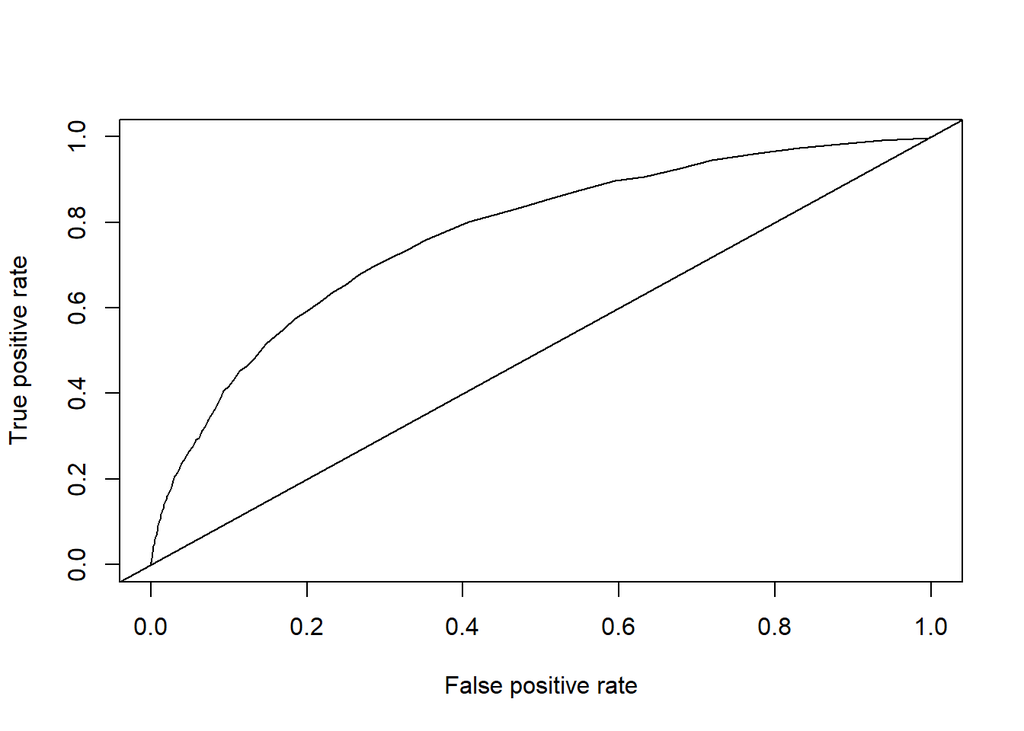

```r
traindata$predprob<- round(fitted(model),2)
predtrain<-prediction(traindata$predprob, traindata$Exited)
perftrain<-performance(predtrain,"tpr","fpr")
plot(perftrain)
abline(0,1)
```

```r
#AUC
auc<-performance(predtrain,"auc")
auc@y.values
```

```
[[1]]
[1] 0.7714391
```

#### Confusion Matrix for Train data

```r
# Predicted Y for train data
traindata$predY<-as.factor(ifelse(traindata$predprob > threshold,1,0))

#Train data confusion Matrix
confusionMatrix(traindata$predY, traindata$Exited, positive="1")
```

```
Confusion Matrix and Statistics

          Reference
Prediction    0    1
         0 3992  432
         1 1583  994

               Accuracy : 0.7122
                 95% CI : (0.7014, 0.7228)
    No Information Rate : 0.7963
    P-Value [Acc > NIR] : 1

                  Kappa : 0.3177

 Mcnemar's Test P-Value : <2e-16

            Sensitivity : 0.6971
            Specificity : 0.7161
         Pos Pred Value : 0.3857
         Neg Pred Value : 0.9024
             Prevalence : 0.2037
         Detection Rate : 0.1420
   Detection Prevalence : 0.3681
      Balanced Accuracy : 0.7066

       'Positive' Class : 1
```

#### ROC Curve and AUC for Test Data

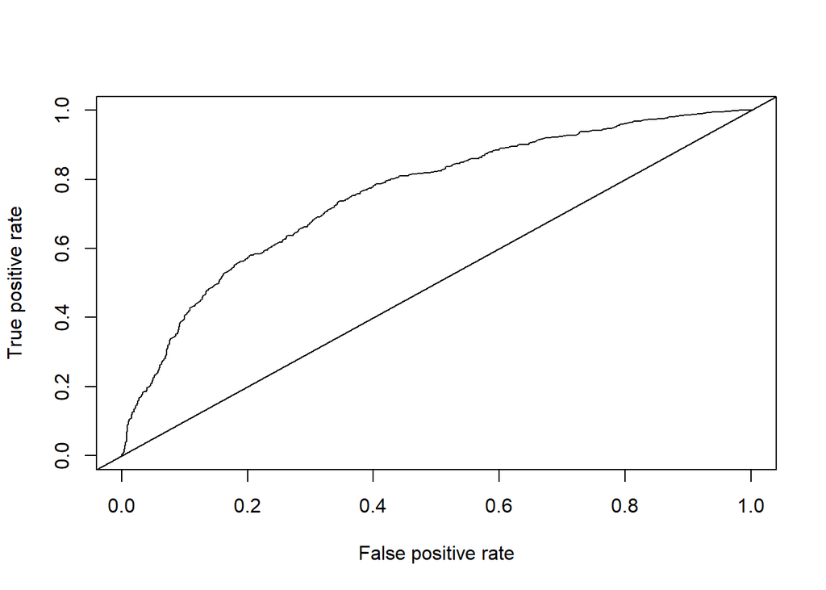

```r
testdata$predprob<-predict(model,testdata,type='response')
pred<-prediction(testdata$predprob,testdata$Exited)
perf<-performance(pred,"tpr","fpr")
plot(perf)
abline(0,1)
```

```r
#Test AUC
auc<-performance(pred,"auc")
auc@y.values
```

```
[[1]]
[1] 0.7556389
```

#### Confusion Matrix for Test data

```r
testdata$predY<- as.factor(ifelse(testdata$predprob > threshold,1,0))
confusionMatrix(testdata$predY,testdata$Exited,positive="1")
```

```
Confusion Matrix and Statistics

          Reference
Prediction    0    1
         0 1670  199
         1  718  412

               Accuracy : 0.6942
                 95% CI : (0.6774, 0.7107)
    No Information Rate : 0.7963
    P-Value [Acc > NIR] : 1

                  Kappa : 0.2839

 Mcnemar's Test P-Value : <2e-16

            Sensitivity : 0.6743
            Specificity : 0.6993
         Pos Pred Value : 0.3646
         Neg Pred Value : 0.8935
             Prevalence : 0.2037
         Detection Rate : 0.1374
   Detection Prevalence : 0.3768
      Balanced Accuracy : 0.6868

       'Positive' Class : 1
```

#### Comment :

The overall model accuracy is 69%. The area under ROC curve is 75.56

### Model 2. Naive Bayes

##### Building Model

```r
model_nb<-naiveBayes(Exited ~ CreditScore+ Geography + Gender + Age + Tenure + Balance + NumOfProducts+
             HasCrCard + IsActiveMember + EstimatedSalary, data = traindata)
```

#### ROC Curve and AUC for Train Data

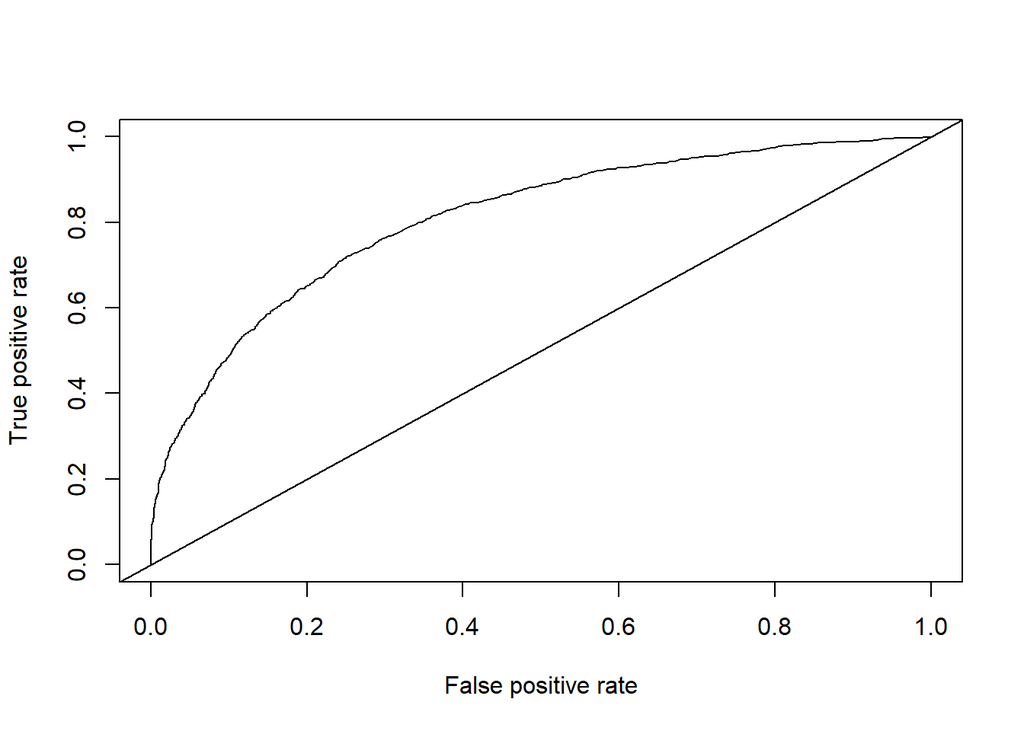

```r
prednb<-predict(model_nb,traindata,type='raw')

#### Computing AUC value for ROC curve
pred<-prediction(prednb[,2],traindata$Exited)
perf<-performance(pred,"tpr","fpr")
plot(perf)
abline(0,1)
```

```r
auc<-performance(pred,"auc")
auc@y.values
```

```
[[1]]
[1] 0.8081089
```

#### Confusion Matrix for train data

```r
traindata$predY<-as.factor(ifelse(prednb[,2] > threshold,1,0))
confusionMatrix(traindata$predY,traindata$Exited,positive="1")
```

```
Confusion Matrix and Statistics

          Reference
Prediction    0    1
         0 4173  398
         1 1402 1028

               Accuracy : 0.7429
                 95% CI : (0.7325, 0.7531)
    No Information Rate : 0.7963
    P-Value [Acc > NIR] : 1

                  Kappa : 0.372

 Mcnemar's Test P-Value : <2e-16

            Sensitivity : 0.7209
            Specificity : 0.7485
         Pos Pred Value : 0.4230
         Neg Pred Value : 0.9129
             Prevalence : 0.2037
         Detection Rate : 0.1468
   Detection Prevalence : 0.3471
      Balanced Accuracy : 0.7347

       'Positive' Class : 1
```

#### ROC Curve and AUC for Test Data

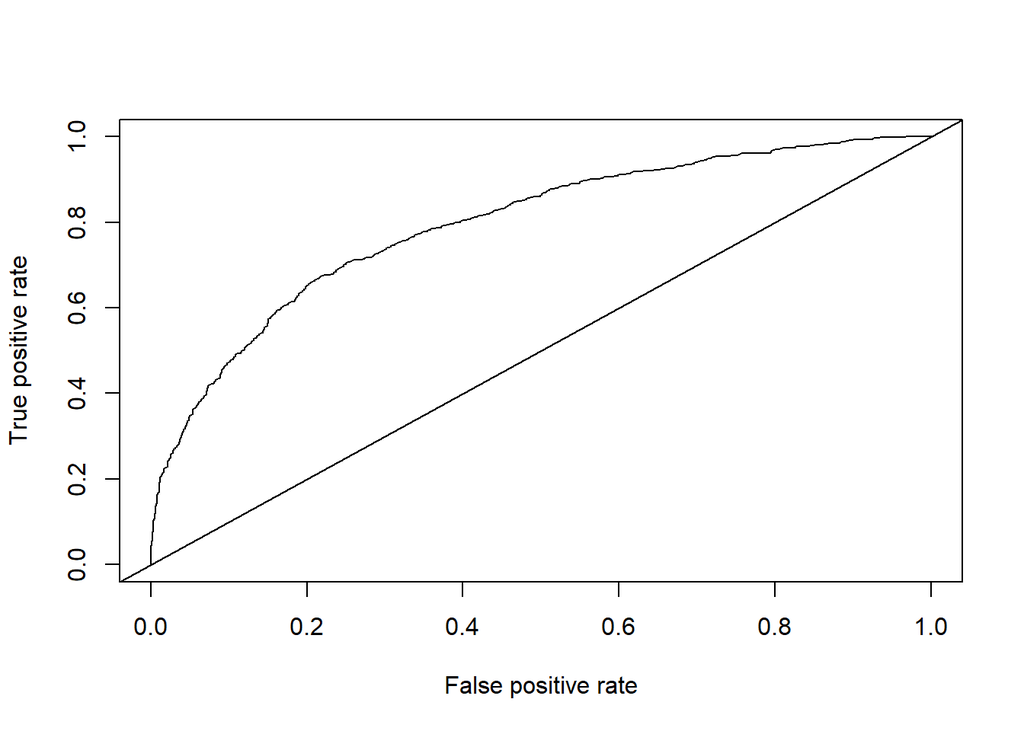

```r
prednb<-predict(model_nb,testdata,type='raw')
#### Computing AUC value for ROC curve
pred<-prediction(prednb[,2],testdata$Exited)
perf<-performance(pred,"tpr","fpr")
plot(perf)
abline(0,1)
```

```r
auc<-performance(pred,"auc")
auc@y.values
```

```
[[1]]
[1] 0.7942556
```

#### Confusion Matrix for test data

```r
testdata$predY<-as.factor(ifelse(prednb[,2] > threshold,1,0))
confusionMatrix(testdata$predY,testdata$Exited,positive="1")
```

```
Confusion Matrix and Statistics

          Reference
Prediction    0    1
         0 1798  184
         1  590  427

               Accuracy : 0.7419
                 95% CI : (0.7259, 0.7575)
    No Information Rate : 0.7963
    P-Value [Acc > NIR] : 1

                  Kappa : 0.3622

 Mcnemar's Test P-Value : <2e-16

            Sensitivity : 0.6989
            Specificity : 0.7529
         Pos Pred Value : 0.4199
         Neg Pred Value : 0.9072
             Prevalence : 0.2037
         Detection Rate : 0.1424
   Detection Prevalence : 0.3391
      Balanced Accuracy : 0.7259

       'Positive' Class : 1
```

##### Observation:

The overall model accuracy is 74%. The area under ROC curve is 79.43

### Model 3. Support Vector Machine (SVM)

#### Building Model

```r
model_svm<-svm(Exited ~ CreditScore+ Geography + Gender + Age + Tenure + Balance + NumOfProducts+
             HasCrCard + IsActiveMember + EstimatedSalary,data = traindata,
               type="C",probability=TRUE,kernel="linear")
model_svm
```

```
Call:
svm(formula = Exited ~ CreditScore + Geography + Gender + Age + Tenure +
    Balance + NumOfProducts + HasCrCard + IsActiveMember + EstimatedSalary,
    data = traindata, type = "C", probability = TRUE, kernel = "linear")


Parameters:
   SVM-Type:  C-classification
 SVM-Kernel:  linear
       cost:  1

Number of Support Vectors:  3044
```

#### ROC Curve and AUC for Train Data

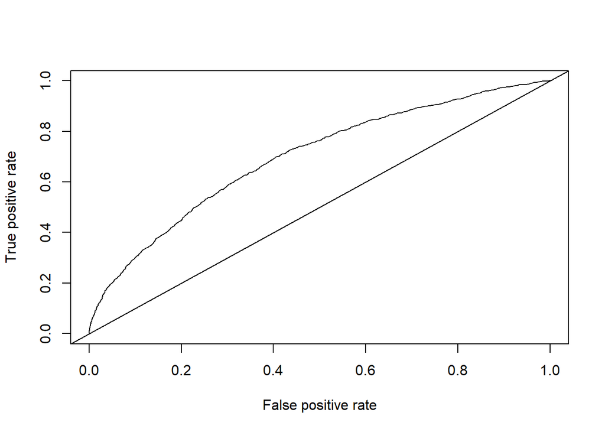

```r
pred1<-predict(model_svm,traindata,probability=TRUE)
pred2<-attr(pred1,"probabilities")[,1]

# Computing AUC value for ROC curve
pred<-prediction(pred2,traindata$Exited)
perf<-performance(pred,"tpr","fpr")
plot(perf)
abline(0,1)
```

```r
auc<-performance(pred,"auc")
auc@y.values
```

```
[[1]]
[1] 0.6968955
```

#### Confusion Matrix for train data

```r
traindata$predY<-as.factor(ifelse(pred2>threshold,1,0))
confusionMatrix(traindata$predY,traindata$Exited,positive="1")
```

```
Confusion Matrix and Statistics

          Reference
Prediction    0    1
         0 3489  480
         1 2086  946

               Accuracy : 0.6335
                 95% CI : (0.6221, 0.6448)
    No Information Rate : 0.7963
    P-Value [Acc > NIR] : 1

                  Kappa : 0.2038

 Mcnemar's Test P-Value : <2e-16

            Sensitivity : 0.6634
            Specificity : 0.6258
         Pos Pred Value : 0.3120
         Neg Pred Value : 0.8791
             Prevalence : 0.2037
         Detection Rate : 0.1351
   Detection Prevalence : 0.4331
      Balanced Accuracy : 0.6446

       'Positive' Class : 1
```

#### ROC Curve and AUC for Test Data

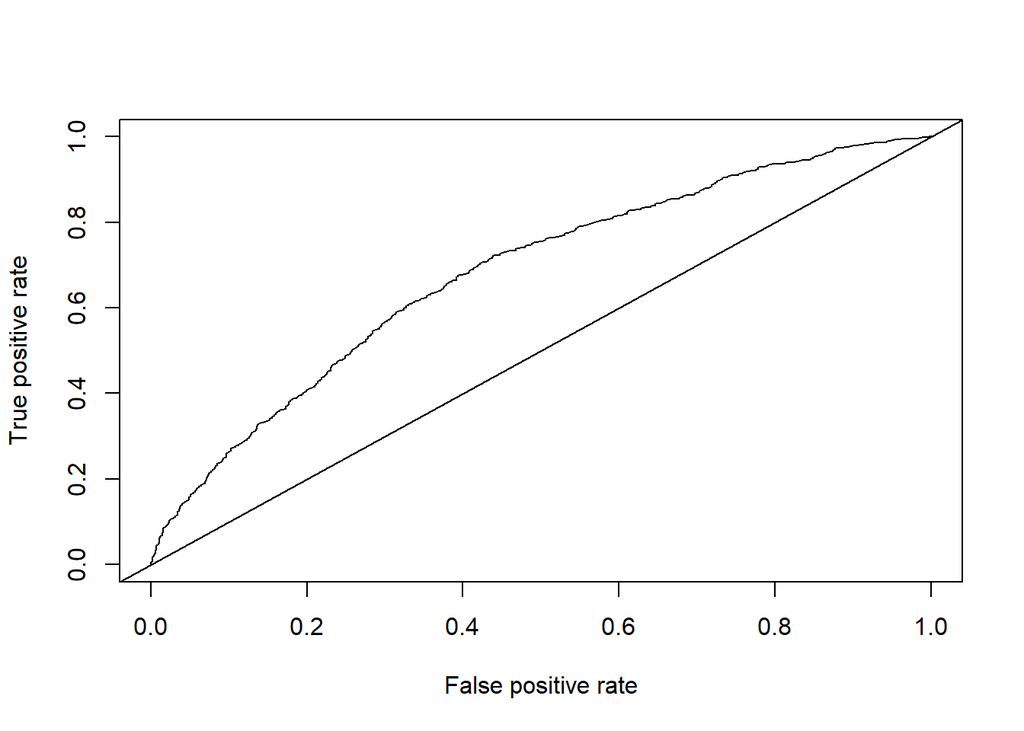

```r
pred1<-predict(model_svm,testdata,probability=TRUE)
pred2<-attr(pred1,"probabilities")[,1]

# Computing AUC value for ROC curve
pred<-prediction(pred2,testdata$Exited)
perf<-performance(pred,"tpr","fpr")
plot(perf)
abline(0,1)
```

```r
auc<-performance(pred,"auc")
auc@y.values
```

```
[[1]]
[1] 0.6806023
```

#### Generate Confusion Matrix

```r
testdata$predY<-as.factor(ifelse(pred2>threshold,1,0))
confusionMatrix(testdata$predY,testdata$Exited,positive="1")
```

```
Confusion Matrix and Statistics

          Reference
Prediction    0    1
         0 1496  217
         1  892  394

               Accuracy : 0.6302
                 95% CI : (0.6126, 0.6475)
    No Information Rate : 0.7963
    P-Value [Acc > NIR] : 1

                  Kappa : 0.1923

 Mcnemar's Test P-Value : <2e-16

            Sensitivity : 0.6448
            Specificity : 0.6265
         Pos Pred Value : 0.3064
         Neg Pred Value : 0.8733
             Prevalence : 0.2037
         Detection Rate : 0.1314
   Detection Prevalence : 0.4288
      Balanced Accuracy : 0.6357

       'Positive' Class : 1
```

#### Observations :

The overall model accuracy is 63%. The area under ROC curve is 68.06

#### Conclusion:

The Navie Bayes method gives highest AUC for test data when compared with BLR and SVM method.